# Day 3 - Bayesian

Now I will count how many columns there are in this model matrix. In this case this is easy - there are seven. But it is useful to have this calculated for use for some circumstances

```r
nX <- ncol(X)
nX
```

```
## [1] 7
```

Now I have to define the parameters and run jags

```r
params<- c("beta","sigma","y.err")
burnInSteps = 2000
nChains = 3
numSavedSteps = 50000
thinSteps = 5
nIter = ceiling((numSavedSteps * thinSteps)/nChains)
nIter
```

```
## [1] 83334
```

```r
loyn.list <- with(loyn,list(y=ABUND, x=X, nX=nX, n=nrow(loyn)))
```

```r
library("R2jags", lib.loc="/Library/Frameworks/R.framework/Versions/3.0/Resources/library")
loyn.r2jags2 <- jags(data=loyn.list,
                    inits=NULL,
                    parameters.to.save=params,
                    model.file="multregression1.txt",
                    n.chains=nChains,
                    n.iter=nIter,
                    n.burnin=burnInSteps,
                    n.thin=thinSteps
                    )
```

```
##    Graph Size: 633
##
```

Now, we can generate the traceplots and decide whether we had enough iterations and appropriate thinning. Were the chains well mixed? Is the posterior likely to be stable?

```r
#quartz()
plot(as.mcmc(loyn.r2jags2))
```

[output not shown]

So now I am specifically indicating only to plot columns 1 to 7, which I know are the intercept and the partial slopes.

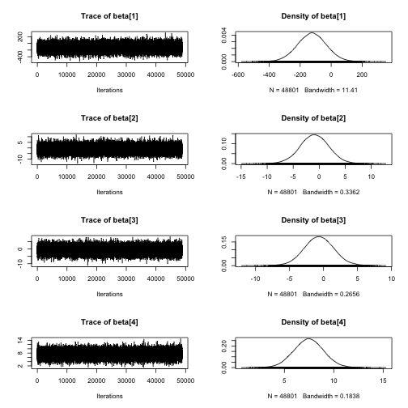

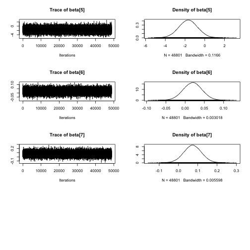

```r
plot(as.mcmc(loyn.r2jags2$BUGSoutput$sims.matrix[,1:7]))
```

Check for autocorrelation

```r
autocorr.diag(as.mcmc(loyn.r2jags2$BUGSoutput$sims.matrix[,c(1:7,9)]))
```

```
##              beta[1]       beta[2]      beta[3]       beta[4]
## Lag 0   1.0000000000  1.0000000000 1.0000000000  1.0000000000
## Lag 1  -0.0034959667  0.0045494743 0.0005564878  0.0003734223
## Lag 5   0.0067478229  0.0006726002 0.0026549923 -0.0061700323
## Lag 10  0.0008315104  0.0022944325 0.0022112913 -0.0058832267
## Lag 50 -0.0002163488 -0.0050211099 0.0039649221 -0.0013151119
##              beta[5]       beta[6]       beta[7]         sigma
## Lag 0   1.0000000000  1.0000000000  1.000000e+00  1.0000000000
## Lag 1  -0.0022975685 -0.0118558538 -2.941502e-03 -0.0009093866
## Lag 5   0.0047833007 -0.0028170656  5.479705e-03  0.0009092211
## Lag 10  0.0007394574  0.0007690748  9.813183e-05 -0.0030403735
## Lag 50 -0.0070120378  0.0056205137  1.076503e-04 -0.0017053282
```

No evidence of autocorrelation.

Now we look at the parameters of the estimates and confidence intervals etc

```r
#print(loyn.r2jags)
```

The first beta will be the intercept. After that, you need to remember what order you put the predictors in the model.matrix. Recall

```
X <- model.matrix(~logDIST+logLDIST+logAREA+GRAZE+ALT+YR.ISOL,data=loyn)
head(X)
```

ANOVA

Fit a single factor ANOVA for the day data modeling the number of newly recruited barnacles against TREAT (substrate type - Algae1, Algae2, Naturally bare and Scraped bare).

```r
day<-(read.csv('day.csv',strip.white=T))
head(day)
```

```
##   TREAT BARNACLE
## 1  ALG1       27
## 2  ALG1       19
## 3  ALG1       18
## 4  ALG1       23
## 5  ALG1       25
## 6  ALG2       24
```

```r
summary(lm(BARNACLE~TREAT,data=day))
```

```
##
## Call:
## lm(formula = BARNACLE ~ TREAT, data = day)
##
## Residuals:
##    Min     1Q Median     3Q    Max
##  -6.00  -2.65  -1.10   2.85   7.00
##
## Coefficients:
##             Estimate Std. Error t value Pr(>|t|)
## (Intercept)   22.400      1.927  11.622 3.27e-09 ***
## TREATALG2      6.000      2.726   2.201  0.04275 *
## TREATNB       -7.400      2.726  -2.715  0.01530 *
## TREATS        -9.200      2.726  -3.375  0.00386 **
## ---
## Signif. codes:  0 '***' 0.001 '**' 0.01 '*' 0.05 '.' 0.1 ' ' 1
##
## Residual standard error: 4.31 on 16 degrees of freedom
## Multiple R-squared:  0.7125, Adjusted R-squared:  0.6586
## F-statistic: 13.22 on 3 and 16 DF,  p-value: 0.0001344
```

Now do a Tukeys test(post-hoc pairwise comparisons). Take note of the power reductions as a result of the Tukey's test

```r
summary(glht(day.lm,linfct=mcp(TREAT="Tukey")))
```

[output not shown]

Recall that the intercept represents the mean of the fisrt treatment group 9the mean number of barnacles on the algae1 substrate) TREATALT2 regpresents the effect (difference between the number of barnacles on the algae2 surface vs the number on algae1). Similary, TREATNB is the difference between NB and ALG1 and so on….

Now lets have a go at this in a Bayesian framework.

```r
modelString="
model {
  for (i in 1:n) {
    barnacle[i]~dnorm(mean[i],tau.res)
    mean[i] <- alpha+beta[treat[i]]
    }
#priors and derivatives
    alpha~dnorm(0,1.0E-6)
    beta[1] <- 0
  for (i in 2:nTreat) {
    beta[i] ~ dnorm(0,1.0E-06) #prior
    }
  tau.res <- 1/ (sigma.res*sigma.res)
  sigma.res~dgamma(0.001,0.001) #prior on sd residulas
  }
"
day.list <- with(day,
                 list(barnacle=BARNACLE,
                      treat=as.numeric(TREAT),
                      n=nrow(day),
                      nTreat=length(levels(TREAT))
                      )
                 )

day.list
```

```
## $barnacle
##  [1] 27 19 18 23 25 24 33 27 26 32  9 13 17 14 22 12  8 15 20 11
##
## $treat
##  [1] 1 1 1 1 1 2 2 2 2 2 3 3 3 3 3 4 4 4 4 4
##
## $n
## [1] 20
##
## $nTreat
## [1] 4
```

```r
writeLines(modelString,con="anova.txt")
```

Note that the differece is the way that beta is defined for categorical variables beta[treat[i]] rather than beta*treat[i]

Since alpha is the intercept (which I just indicated was the mean of the first treatment), we need to set the first effect prior to zero.. beta[1] <- 0

What data do we need to supply to JAGS?

- barnacle - the response vector
- treat - the categorical vector (HOWEVER MUST BE NUMBERS, NOT WORDS)
- n - the number of rows in the data set.
- nTreat - the number of treatments

Notice that the TREAT categorical variable is now integers.

Now define the parameters etc that you want to get back from JAGS as well as the MCMC parameters (number of iterations etc)

```r
params <- c("alpha","beta","sigma.res")
burInSteps = 200
nChains =3
numSavedSteps = 5000
thinSteps = 10
nIter = ceiling((numSavedSteps * thinSteps)/nChains)
```

```r
library("R2jags", lib.loc="/Library/Frameworks/R.framework/Versions/3.0/Resources/library")
day.r2jags1<- jags(data=day.list,
                    inits=NULL,
                    parameters.to.save=params,
                    model.file="anova.txt",
                    n.chains=nChains,
                    n.iter=nIter,
                    n.burnin=burnInSteps,
                    n.thin=thinSteps
                    )
```

```
##    Graph Size: 58
##
```

Check the traceplots and autocorrelation.

```r
plot(as.mcmc(day.r2jags1))
```

[output not shown]

```r
autocorr.diag(as.mcmc(day.r2jags1))
```

[output not shown]

```
print(day.r2jags1)
```

So how about the explore other comparisons. What about we compare each group to each toher group. What about also exploring specific comparisons such as the average of treatment (NB and S) vs (ALG2 and ALG1)

We can either do this inside of JAGS, or outside of JAGS.

Lets start withinside of JAGS, we just have to make a couple of modifications to the JAGS model…

```r
modelString="
model {
  for (i in 1:n) {
    barnacle[i]~dnorm(mean[i],tau.res)
    mean[i] <- alpha+beta[treat[i]]
    }
#priors and derivatives
    alpha~dnorm(0,1.0E-6)
    beta[1] <- 0
  for (i in 2:nTreat) {
    beta[i] ~ dnorm(0,1.0E-06) #prior
    }
  tau.res <- 1/ (sigma.res*sigma.res)
  sigma.res~dgamma(0.001,0.001) #prior on sd residuals
#Group mean derivatives
  for (i in 1:nTreat) {
    Treatment.means[i] <- beta[i]+alpha
}
#pairwise effects
for (j in 1:nTreat){
for (i in 1:nTreat){
eff[j,i] <- Treatment.means[j] - Treatment.means[i]
}
}
#Bare vs Algae
comp1 <- ((Treatment.means[3]+Treatment.means[4])/2) - ((Treatment.means[1]+Treatment.means[2])/2)
}
"
writeLines(modelString,con="anova2.txt")
```

Firstly, we are calculating the mean of each group from the effects. Since effects are expressed relative to the first group, each of the treatment means must just be the effect (beta) plu the intercept (first groups mean)

Once you have the treatment means, you can come up with any comparison. The first set that is created (after the #pairwise effects) is a double loop so as to compare each treatment with each other treatment (yes, that will mean we are comparing ALG1 with ALG1 which is obviously pointless and we will aslo have ALG1 vc ALG2 and ALG2 vs ALG1 which are obviously the same thing, but is doesn't really cost anything and it makes the code a little shorter)

Finally, we have a planned comparison (contrast) comparing the average of the bare surfaces to the average of the bare surfaces to the average of the algae surfaces (and we have called this comparison comp1\ )

following stays the same:

```
day.list <- with(day,
                 list(barnacle=BARNACLE,
                      treat=as.numeric(TREAT),
                      n=nrow(day),
                      nTreat=length(levels(TREAT))
                      )
                 )
burInSteps = 200
nChains =3
numSavedSteps = 5000
thinSteps = 10
nIter = ceiling((numSavedSteps * thinSteps)/nChains)
```

Add the new stuff we want to get from JAGS

```r
params <- c("alpha","beta","sigma.res","Treatment.means","eff","comp1")
```

```r
library("R2jags", lib.loc="/Library/Frameworks/R.framework/Versions/3.0/Resources/library")
day.r2jags2<- jags(data=day.list,
                    inits=NULL,
                    parameters.to.save=params,
                    model.file="anova2.txt",
                    n.chains=nChains,
                    n.iter=nIter,
                    n.burnin=burnInSteps,
                    n.thin=thinSteps
                    )
```

```
##    Graph Size: 84
##
```

Check the traceplots and autocorrelation.

```r
plot(as.mcmc(day.r2jags2))
```

[output not shown]

```r
autocorr.diag(as.mcmc(day.r2jags2))
```

[output not shown]

The key here is generating the treatment means (Treatment.means [1] etc)

Imagine you had four colums in a spreadsheet each representing the population values for the four treatments. If you wanted to know whether treatment 1 was different to treatment 2, you would just calulate the means of both and compare them (taking into consideration their confidence intercals). The point is, once you hace those samples, everything is simple.

Tale a look at some of the pairwise comparisons. eff[1,2] represents ALG1 vs ALG2 eff[2,3] represents ALG2 vs NB etc and no loss of powe.

We can compare as many as we have sensible hypotheses about. No adjustments required. comp1 represents Bare vs Algae substrates.

Hypothesis tests are then based on credibility intervals (do they include 0 or not)

We could have fit he anova model using the regression Bayesian model that we defined earlier - the one with the inprod. The model matrix we would supply to it is

```r
X <- model.matrix(~TREAT,data=day)
nX <- ncol(X)
day.list <- list(y=day$BARNACLE, x=X, nX=nX, n=nrow(day))
```

All else would be the same.

```r
library("R2jags", lib.loc="/Library/Frameworks/R.framework/Versions/3.0/Resources/library")
day.r2jags3<- jags(data=day.list,
                    inits=NULL,
                    parameters.to.save=c('beta','sigma'),
                    model.file="multregression1.txt",
                    n.chains=nChains,
                    n.iter=nIter,
                    n.burnin=burnInSteps,
                    n.thin=thinSteps
                    )
```

```
##    Graph Size: 158
##
```

Look at X (the model.matrix), see how it's dummy coded.

```r
head(X)
```

```
##   (Intercept) TREATALG2 TREATNB TREATS
## 1           1         0       0      0
## 2           1         0       0      0
## 3           1         0       0      0
## 4           1         0       0      0
## 5           1         0       0      0
## 6           1         1       0      0
```

That one model (multregression) can be used for any multiple regression or anova (including factorial anova or ancova)

Last thing, lets modify it for poisson regression.

```r
modelString="
model {
  for (i in 1:n) {
    y[i]~dpois(mu[i])
    log(mu[i]) <- inprod(beta[],x[i,])
    y.err[i] <- y[i] - mu[i]
    }
for (i in 1:nX) {
    beta[i] ~ dnorm(0,1.0E-06) #prior
    }
}
"
writeLines(modelString,con="poissonregression.txt")
```

Notice that we no longer have tau, since the poisson distribution is only defined by mu (the center). Instead of mu <- inprod() we have log(mu[i]) <- inprod The log is the link fundtion (appropriate for poisson)

Then just re-run jags (TAKE OUT SIGMA from the parameters.to.save) Note, it will be a bit slower and technically, we should have increased the number of burnins to 50%

Also remember that the parameter estimates are on a log scale, but can easily be back-transformed using exp()

```r
library("R2jags", lib.loc="/Library/Frameworks/R.framework/Versions/3.0/Resources/library")
day.r2jags3<- jags(data=day.list,
                    inits=NULL,
                    parameters.to.save=c('beta'),
                    model.file="poissonregression.txt",
                    n.chains=nChains,
                    n.iter=nIter,
                    n.burnin=burnInSteps,
                    n.thin=thinSteps
                    )
```

```
## module glm loaded
```

```
##    Graph Size: 157
##
```

Actually, what you should do is first calculate the treatment means (eg. exp(beta[1]) is the mean of ALG1, treatment mean of algae 2 = exp(beta[2] +beta[1]) That is, do the addition and make the back transform the last operation.

But otherwise, glm is not any more difficult that lm in Bayesian.